# Univariate: Saliva COVID-19

Jose Tamez

2023-05-23

# 1 COVID_19 Univariate

### 1.0.1 Loading the libraries

```r
library("FRESA.CAD")
library(readxl)
op <- par(no.readonly = TRUE)
pander::panderOptions('digits', 3)
pander::panderOptions('table.split.table', 400)
pander::panderOptions('keep.trailing.zeros',TRUE)
```

## 1.1 Data: The COVID_19 Data-Set

The data to process is described in:

https://zenodo.org/record/4156647#.Y1bSF3bMKUk

Thermal Saliva Testing Dataset

10.5281/zenodo.4156647 https://doi.org/10.5281/zenodo.4156647

I added a column to the data identifying the repeated experiments.

```r
SalivaThermal <- as.data.frame(read_excel("~/GitHub/FCA/Data/SalivaThermal_Source_Data_2.xlsx"))


SalivaThermal_set1 <- subset(SalivaThermal,RepID==1)
rownames(SalivaThermal_set1) <- SalivaThermal_set1$ID
SalivaThermal_set1$RepID <- NULL
SalivaThermal_set1$ID <- NULL
SalivaThermal_set1$Ct <- NULL

SalivaThermal_set2 <- subset(SalivaThermal,RepID==2)
rownames(SalivaThermal_set2) <- SalivaThermal_set2$ID
SalivaThermal_set2$RepID <- NULL
SalivaThermal_set2$ID <- NULL
SalivaThermal_set2$Ct <- NULL

SalivaThermal_set3 <- subset(SalivaThermal,RepID==3)
rownames(SalivaThermal_set3) <- SalivaThermal_set3$ID
SalivaThermal_set3$RepID <- NULL
SalivaThermal_set3$ID <- NULL
SalivaThermal_set3$Ct <- NULL

SalivaThermal_Avg <- (SalivaThermal_set1 + SalivaThermal_set2 + SalivaThermal_set3)/3

colnames(SalivaThermal_Avg) <- paste("V",colnames(SalivaThermal_Avg),sep="_")

SalivaThermal_Avg$class <- 1*(str_detect(rownames(SalivaThermal_Avg),"P"))
```

#### 1.1.0.1 Standarize the names for the reporting

```r
dataframe <- SalivaThermal_Avg
outcome <- "class"
```

```r
pander::pander(c(rows=nrow(dataframe),col=ncol(dataframe)-1))
```

| rows | col |
| --- | --- |
| 61 | 251 |

```r
pander::pander(table(dataframe[,outcome]))
```

| 0 | 1 |
| --- | --- |
| 30 | 31 |

```r
varlist <- colnames(dataframe)
varlist <- varlist[varlist != outcome]
varlist <- as.data.frame(cbind(name=varlist,desc=varlist))
```

## 1.2 Univariate

```r
univariate_columns <- c("caseMean","caseStd","controlMean","controlStd","controlKSP","ROCAUC","WilcoxRes.p","FRes.p")
univar <- uniRankVar(varlist,
               paste(outcome,"~1"),
               outcome,
               dataframe,
               categorizationType = "Raw",
               type = "LOGIT",
               rankingTest = "AUC",
                cateGroups = c(0.1, 0.9),
                raw.dataFrame = NULL,
                description = ".",
                uniType = "Binary")
```

100 : V_1102 200 : V_902

```r
pander::pander(univar$orderframe[1:20,univariate_columns])
```

|  | caseMean | caseStd | controlMean | controlStd | controlKSP | ROCAUC | WilcoxRes.p | FRes.p |
| --- | --- | --- | --- | --- | --- | --- | --- | --- |
| **V_908** | 0.221 | 0.128 | 0.261 | 0.117 | 0.579 | 0.596 | 0.108 | 0.1000 |
| **V_906** | 0.220 | 0.127 | 0.261 | 0.117 | 0.585 | 0.596 | 0.111 | 0.0987 |
| **V_904** | 0.220 | 0.127 | 0.261 | 0.117 | 0.592 | 0.596 | 0.111 | 0.0976 |
| **V_892** | 0.219 | 0.127 | 0.261 | 0.121 | 0.626 | 0.596 | 0.115 | 0.0944 |
| **V_890** | 0.219 | 0.127 | 0.261 | 0.121 | 0.616 | 0.596 | 0.118 | 0.0956 |
| **V_888** | 0.219 | 0.127 | 0.261 | 0.122 | 0.603 | 0.596 | 0.119 | 0.0973 |
| **V_912** | 0.223 | 0.129 | 0.263 | 0.117 | 0.604 | 0.595 | 0.111 | 0.1023 |
| **V_910** | 0.222 | 0.128 | 0.262 | 0.117 | 0.587 | 0.595 | 0.111 | 0.1011 |
| **V_896** | 0.220 | 0.127 | 0.261 | 0.120 | 0.620 | 0.595 | 0.119 | 0.0941 |
| **V_894** | 0.219 | 0.127 | 0.261 | 0.121 | 0.625 | 0.595 | 0.117 | 0.0939 |
| **V_886** | 0.219 | 0.128 | 0.261 | 0.122 | 0.602 | 0.595 | 0.119 | 0.0990 |
| **V_916** | 0.226 | 0.131 | 0.266 | 0.118 | 0.634 | 0.594 | 0.114 | 0.1067 |
| **V_914** | 0.225 | 0.130 | 0.265 | 0.118 | 0.621 | 0.594 | 0.112 | 0.1041 |
| **V_902** | 0.220 | 0.127 | 0.261 | 0.118 | 0.599 | 0.594 | 0.118 | 0.0966 |
| **V_900** | 0.220 | 0.127 | 0.261 | 0.118 | 0.607 | 0.594 | 0.118 | 0.0957 |
| **V_898** | 0.220 | 0.127 | 0.261 | 0.119 | 0.614 | 0.594 | 0.119 | 0.0948 |
| **V_884** | 0.220 | 0.128 | 0.261 | 0.122 | 0.606 | 0.594 | 0.124 | 0.1003 |
| **V_918** | 0.228 | 0.132 | 0.267 | 0.119 | 0.617 | 0.592 | 0.117 | 0.1098 |
| **V_882** | 0.220 | 0.129 | 0.261 | 0.123 | 0.607 | 0.592 | 0.125 | 0.1013 |
| **V_880** | 0.221 | 0.129 | 0.262 | 0.124 | 0.608 | 0.592 | 0.125 | 0.1019 |

```r
topfiveOrg <- rownames(univar$orderframe[1:5,])
```

## 1.3 Decorrelation Analysis

```r
DEdataframe <- IDeA(dataframe,thr=0.80,verbose = TRUE)
```

Included: 251 , Uni p: 0.0499003 , Uncorrelated Base: 1 , Outcome-Driven Size: 0 , Base Size: 1

1 <R=1.000,w= 1,N= 251>, Top: 3( 71 )1 : 3 : 0.975,<|>Tot Used: 251 , Added: 248 , Zero Std: 0 , Max Cor: 1.000

2 <R=1.000,w= 1,N= 251>, Top: 25( 7 )=2 : 25 : 0.989,<|>Tot Used: 251 , Added: 138 , Zero Std: 0 , Max Cor: 0.999

3 <R=0.999,w= 1,N= 251>, Top: 57( 3 )1 : 57 : 0.975,<|>Tot Used: 251 , Added: 100 , Zero Std: 0 , Max Cor: 0.999

4 <R=0.999,w= 1,N= 251>, Top: 38( 2 )1 : 38 : 0.975,<|>Tot Used: 251 , Added: 55 , Zero Std: 0 , Max Cor: 0.999

5 <R=0.999,w= 1,N= 251>, Top: 13( 1 )1 : 13 : 0.974,<|>Tot Used: 251 , Added: 16 , Zero Std: 0 , Max Cor: 0.995

6 <R=0.995,w= 2,N= 104>, Top: 43( 2 )1 : 43 : 0.948,<|>Tot Used: 251 , Added: 49 , Zero Std: 0 , Max Cor: 1.000

7 <R=1.000,w= 2,N= 104>, Top: 19( 1 )1 : 19 : 0.950,<|>Tot Used: 251 , Added: 20 , Zero Std: 0 , Max Cor: 0.991

8 <R=0.991,w= 2,N= 104>, Top: 10( 1 )1 : 10 : 0.946,<|>Tot Used: 251 , Added: 10 , Zero Std: 0 , Max Cor: 0.993

9 <R=0.993,w= 3,N= 111>, Top: 46( 2 )1 : 46 : 0.897,<|>Tot Used: 251 , Added: 54 , Zero Std: 0 , Max Cor: 0.998

10 <R=0.998,w= 3,N= 111>, Top: 25( 1 )1 : 25 : 0.899,<|>Tot Used: 251 , Added: 27 , Zero Std: 0 , Max Cor: 0.992

11 <R=0.992,w= 3,N= 111>, Top: 7( 1 )1 : 7 : 0.896,<|>Tot Used: 251 , Added: 7 , Zero Std: 0 , Max Cor: 0.895

12 <R=0.895,w= 4,N= 126>, Top: 45( 3 )1 : 45 : 0.800,<|>Tot Used: 251 , Added: 61 , Zero Std: 0 , Max Cor: 0.984

13 <R=0.984,w= 4,N= 126>, Top: 17( 1 )1 : 17 : 0.842,<|>Tot Used: 251 , Added: 18 , Zero Std: 0 , Max Cor: 0.963

14 <R=0.963,w= 4,N= 126>, Top: 9( 1 )1 : 9 : 0.832,<|>Tot Used: 251 , Added: 9 , Zero Std: 0 , Max Cor: 0.964

15 <R=0.964,w= 5,N= 16>, Top: 7( 1 )1 : 7 : 0.800,<|>Tot Used: 251 , Added: 7 , Zero Std: 0 , Max Cor: 0.797

16 <R=0.000,w= 5,N= 16>

[ 16 ], 0.7971747 Decor Dimension: 251 . Cor to Base: 75 , ABase: 1 , Outcome Base: 0

```r
pander::pander(c(Decorrleated_Fraction=sum(str_detect(colnames(DEdataframe),"La_"))/(ncol(DEdataframe)-1)))
```

| Decorrleated_Fraction |
| --- |
| 0.996 |

```r
demat <- attr(DEdataframe,"UPSTM")
pander::pander(c(sparse_Fraction=1.0-sum(demat==0)/ncol(demat)/nrow(demat)))
```

| sparse_Fraction |
| --- |
| 0.0183 |

```r
varlistDe <-  colnames(DEdataframe)[colnames(DEdataframe) != "class"];
varlistDe <- as.data.frame(cbind(name=varlistDe,desc=varlistDe))
```

### 1.3.1 The heat maps.

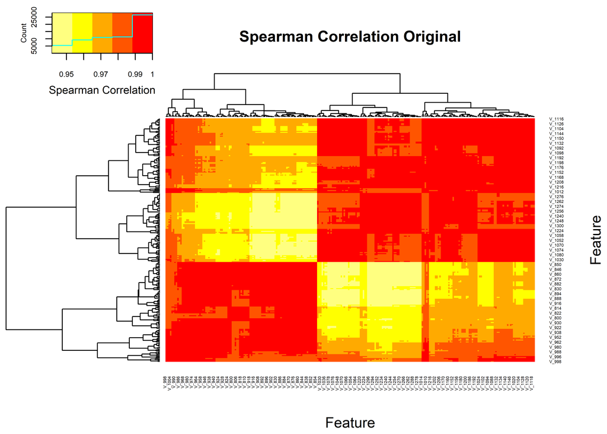

```r
par(cex=0.6,cex.main=0.85,cex.axis=0.7)
cormat <- cor(dataframe[,rownames(demat)],method="spearman")
cormat[is.na(cormat)] <- 0
gplots::heatmap.2(abs(cormat),
                  trace = "none",
#                  scale = "row",
                  mar = c(5,5),
                  col=rev(heat.colors(5)),
                  main = "Spearman Correlation Original",
                  cexRow = 0.35,
                  cexCol = 0.35,
                  key.title=NA,
                  key.xlab="Spearman Correlation",
                  xlab="Feature", ylab="Feature")
```

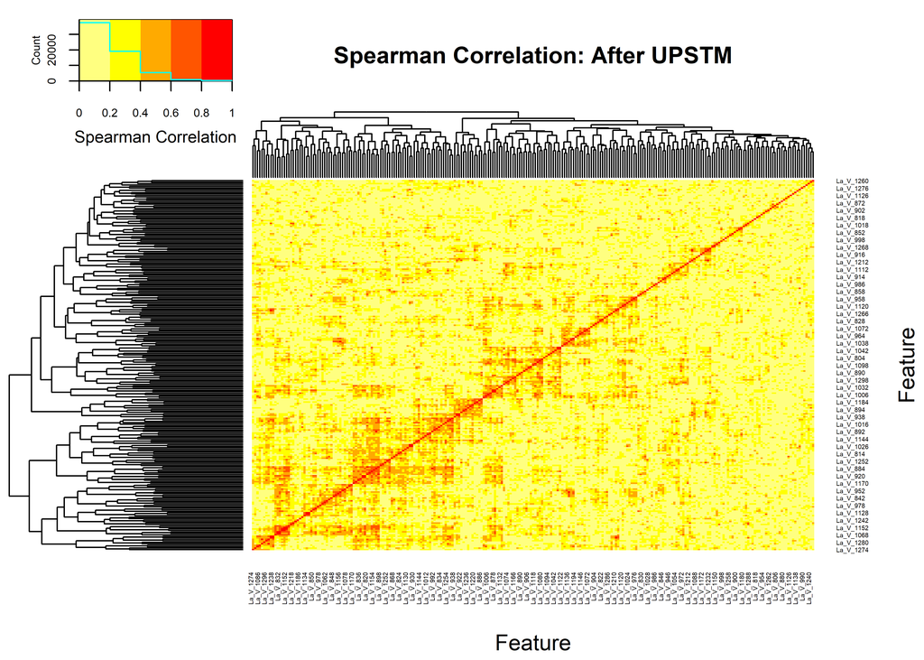

```r
cormat <- cor(DEdataframe[,colnames(demat)],method="spearman")
cormat[is.na(cormat)] <- 0
gplots::heatmap.2(abs(cormat),
                  trace = "none",
#                  scale = "none",
                  mar = c(5,5),
                  col=rev(heat.colors(5)),
                  main = "Spearman Correlation: After UPSTM",
                  cexRow = 0.35,
                  cexCol = 0.35,
                  key.title=NA,
                  key.xlab="Spearman Correlation",
                  xlab="Feature", ylab="Feature")
```

```r
par(op)
```

## 1.4 Univariate Decorrelated

```r
univarDe <- uniRankVar(varlistDe,
              paste(outcome,"~1"),
                outcome,
              DEdataframe,
                categorizationType = "Raw",
                type = "LOGIT",
                rankingTest = "AUC",
                cateGroups = c(0.1, 0.9),
                raw.dataFrame = NULL,
                description = ".",
                uniType = "Binary")
```

100 : La_V_1102 200 : La_V_902

```r
pander::pander(univarDe$orderframe[1:20,univariate_columns])
```

|  | caseMean | caseStd | controlMean | controlStd | controlKSP | ROCAUC | WilcoxRes.p | FRes.p |
| --- | --- | --- | --- | --- | --- | --- | --- | --- |
| **La_V_1152** | -3.33e-05 | 4.43e-04 | 2.84e-04 | 3.24e-04 | 0.0135 | 0.844 | 1.62e-06 | 1.82e-07 |
| **La_V_892** | -7.84e-05 | 1.82e-04 | 9.16e-05 | 1.61e-04 | 0.0661 | 0.837 | 2.30e-06 | 1.03e-06 |
| **La_V_884** | -7.76e-05 | 7.12e-04 | -5.00e-04 | 2.60e-04 | 0.5676 | 0.809 | 1.60e-05 | 8.47e-05 |
| **La_V_1202** | 3.85e-04 | 9.12e-04 | 1.32e-03 | 9.81e-04 | 0.8718 | 0.790 | 4.27e-05 | 2.95e-05 |
| **La_V_910** | 9.55e-04 | 6.88e-03 | 6.36e-03 | 6.77e-03 | 0.3067 | 0.783 | 7.90e-05 | 3.56e-04 |
| **La_V_1230** | -1.21e-03 | 1.52e-03 | -2.56e-03 | 1.29e-03 | 0.8270 | 0.775 | 9.12e-05 | 6.91e-05 |
| **La_V_1050** | 4.15e-04 | 4.79e-03 | -2.70e-03 | 3.07e-03 | 0.4814 | 0.761 | 2.10e-04 | 2.35e-04 |
| **La_V_1156** | 1.22e-02 | 1.34e-02 | -1.38e-03 | 1.54e-02 | 0.0725 | 0.759 | 2.05e-04 | 6.63e-05 |
| **La_V_820** | 1.95e-03 | 1.29e-02 | -7.65e-03 | 7.75e-03 | 0.4522 | 0.759 | 1.74e-04 | 1.63e-04 |
| **La_V_1176** | 1.05e-05 | 4.50e-04 | -1.53e-04 | 2.45e-04 | 0.2626 | 0.757 | 3.23e-04 | 1.82e-02 |
| **La_V_1190** | -1.90e-05 | 3.80e-05 | -4.56e-05 | 2.76e-05 | 0.8128 | 0.741 | 6.14e-04 | 6.75e-04 |
| **La_V_1032** | -3.85e-05 | 3.34e-04 | 1.96e-04 | 1.73e-04 | 0.9371 | 0.737 | 8.91e-04 | 2.61e-04 |
| **La_V_936** | 7.44e-06 | 6.56e-05 | -4.31e-05 | 8.39e-05 | 0.3318 | 0.729 | 9.58e-04 | 2.54e-03 |
| **La_V_834** | 6.98e-04 | 1.65e-03 | -4.88e-04 | 1.72e-03 | 0.0281 | 0.726 | 9.58e-04 | 1.36e-03 |
| **La_V_1046** | 3.04e-04 | 1.12e-03 | -2.15e-04 | 5.34e-04 | 0.1737 | 0.724 | 1.31e-03 | 6.58e-03 |
| **La_V_912** | 3.98e-06 | 5.19e-05 | 3.16e-05 | 6.09e-05 | 0.1195 | 0.717 | 4.19e-03 | 2.02e-02 |
| **La_V_992** | 4.06e-05 | 2.01e-04 | -8.61e-05 | 1.26e-04 | 0.7944 | 0.715 | 1.69e-03 | 1.35e-03 |
| **La_V_1068** | -1.05e-05 | 1.35e-04 | 7.41e-05 | 1.09e-04 | 0.0628 | 0.714 | 1.65e-03 | 2.40e-03 |
| **La_V_1222** | -1.89e-05 | 1.28e-04 | 6.86e-05 | 1.34e-04 | 0.4021 | 0.710 | 6.22e-03 | 4.84e-03 |
| **La_V_942** | 6.53e-05 | 1.76e-04 | -3.42e-05 | 1.15e-04 | 0.7746 | 0.710 | 2.54e-03 | 3.21e-03 |

### 1.4.1 Comparing Decorrelation vs Original

```r
pthr <- 0.20/(ncol(dataframe)-1)

topDecorNames <- rownames(univarDe$orderframe[univarDe$orderframe$FRes.p<pthr,])
topDecorNames <- unique(c(topDecorNames,rownames(univarDe$orderframe[1:5,])))

#topDecorNames <- rownames(univarDe$orderframe[univarDe$orderframe$FRes.p<1.0e-5,])
dc <- getLatentCoefficients(DEdataframe)
### 2a Get only the ones that in the top features
deNames_in_dc <- topDecorNames[topDecorNames %in% names(dc)]
selectedlist <- dc[deNames_in_dc]
theDeFormulas <- selectedlist

rawuniv <- univariate_Wilcoxon(dataframe,outcome,limit=-1)
deuniv <- univariate_Wilcoxon(DEdataframe,outcome,limit=-1)
matsize <- (ncol(dataframe)-1)^2
nocorrelated <- ncol(dataframe) - 1 - ncol(demat)
pander::pander(c(sparse_Fraction=(sum(demat != 0) + nocorrelated)/matsize))
```

| sparse_Fraction |
| --- |
| 0.0183 |

```r
pander::pander(c(raw=length(rawuniv),decor=length(deuniv)))
```

| raw | decor |
| --- | --- |
| 1 | 72 |

```r
pander::pander(c(Number_Latent=length(dc)))
```

| Number_Latent |
| --- |
| 250 |

```r
pander::pander(c(meanSize=mean(sapply(dc,length))))
```

| meanSize |
| --- |
| 4.61 |

## 1.5 CV ROC Analysis

```r
par(op)
par(mfrow=c(1,2),cex=0.9)
fraction <-0.70
repetitions <- 100

fcout <- round(fraction*nrow(dataframe)/15+1.0)
pander::pander(c(NumberofFeatures=fcout))
```

| NumberofFeatures |
| --- |
| 4 |

```r
cvRaw <- randomCV(dataframe,
                outcome,
                fittingFunction= filteredFit,
                classSamplingType = "Pro",
                trainFraction = fraction,
                repetitions = repetitions,
#                fitmethod=  glm,
                fitmethod=  KNN_method,
                filtermethod=mRMR.classic_FRESA,
                filtermethod.control=list(feature_count= fcout),
#                family="binomial"
)
```

……….10 Tested: 60 Avg. Selected: 4 Min Tests: 1 Max Tests: 7 Mean Tests: 3.166667 . MAD: 0.4616667

……….20 Tested: 61 Avg. Selected: 4 Min Tests: 2 Max Tests: 14 Mean Tests: 6.229508 . MAD: 0.4606313

……….30 Tested: 61 Avg. Selected: 4 Min Tests: 4 Max Tests: 18 Mean Tests: 9.344262 . MAD: 0.4703893

……….40 Tested: 61 Avg. Selected: 4 Min Tests: 5 Max Tests: 21 Mean Tests: 12.45902 . MAD: 0.4678376

……….50 Tested: 61 Avg. Selected: 4 Min Tests: 6 Max Tests: 24 Mean Tests: 15.57377 . MAD: 0.4704528

……….60 Tested: 61 Avg. Selected: 4 Min Tests: 11 Max Tests: 29 Mean Tests: 18.68852 . MAD: 0.474356

……….70 Tested: 61 Avg. Selected: 4 Min Tests: 12 Max Tests: 35 Mean Tests: 21.80328 . MAD: 0.4756831

……….80 Tested: 61 Avg. Selected: 4 Min Tests: 14 Max Tests: 39 Mean Tests: 24.91803 . MAD: 0.4741998

……….90 Tested: 61 Avg. Selected: 4 Min Tests: 15 Max Tests: 43 Mean Tests: 28.03279 . MAD: 0.4717213

……….100 Tested: 61 Avg. Selected: 4 Min Tests: 18 Max Tests: 44 Mean Tests: 31.14754 . MAD: 0.4721116

```r
bpraw <- predictionStats_binary(cvRaw$medianTest,"RAW",cex=0.75)
```

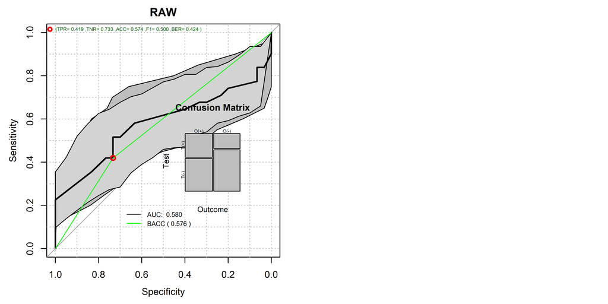

```r
pander::pander(bpraw$CM.analysis$tab)
```

|  | Outcome + | Outcome - | Total |
| --- | --- | --- | --- |
| **Test +** | 13 | 8 | 21 |
| **Test -** | 18 | 22 | 40 |
| **Total** | 31 | 30 | 61 |

```r
pander::pander(bpraw$accc)
```

| est | lower | upper |
| --- | --- | --- |
| 0.574 | 0.441 | 0.7 |

```r
pander::pander(bpraw$aucs)
```

| est | lower | upper |
| --- | --- | --- |
| 0.58 | 0.43 | 0.73 |

```r
pander::pander(bpraw$berror)
```

| 50% | 2.5% | 97.5% |
| --- | --- | --- |
| 0.423 | 0.313 | 0.545 |

```r
cvDe <- randomCV(DEdataframe,
                outcome,
                fittingFunction= filteredFit,
                trainSampleSets= cvRaw$trainSamplesSets,
#                fitmethod=  glm,
                fitmethod=  KNN_method,
                filtermethod=mRMR.classic_FRESA,
                filtermethod.control=list(feature_count= fcout),
#                family="binomial"
)
```

……….10 Tested: 60 Avg. Selected: 4 Min Tests: 1 Max Tests: 7 Mean Tests: 3.166667 . MAD: 0.4103968

……….20 Tested: 61 Avg. Selected: 4 Min Tests: 2 Max Tests: 14 Mean Tests: 6.229508 . MAD: 0.3851093

……….30 Tested: 61 Avg. Selected: 4 Min Tests: 4 Max Tests: 18 Mean Tests: 9.344262 . MAD: 0.3680328

……….40 Tested: 61 Avg. Selected: 4 Min Tests: 5 Max Tests: 21 Mean Tests: 12.45902 . MAD: 0.3552888

……….50 Tested: 61 Avg. Selected: 4 Min Tests: 6 Max Tests: 24 Mean Tests: 15.57377 . MAD: 0.3609485

……….60 Tested: 61 Avg. Selected: 4 Min Tests: 11 Max Tests: 29 Mean Tests: 18.68852 . MAD: 0.3564988

……….70 Tested: 61 Avg. Selected: 4 Min Tests: 12 Max Tests: 35 Mean Tests: 21.80328 . MAD: 0.3507806

……….80 Tested: 61 Avg. Selected: 4 Min Tests: 14 Max Tests: 39 Mean Tests: 24.91803 . MAD: 0.3463895

……….90 Tested: 61 Avg. Selected: 4 Min Tests: 15 Max Tests: 43 Mean Tests: 28.03279 . MAD: 0.3465652

……….100 Tested: 61 Avg. Selected: 4 Min Tests: 18 Max Tests: 44 Mean Tests: 31.14754 . MAD: 0.3483216

```r
bpDecor <- predictionStats_binary(cvDe$medianTest,"Decorrelated",cex=0.75)
```

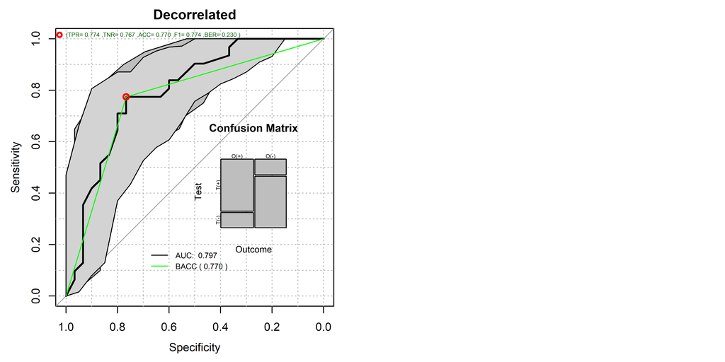

```r
par(op)

pander::pander(bpDecor$CM.analysis$tab)
```

|  | Outcome + | Outcome - | Total |
| --- | --- | --- | --- |
| **Test +** | 24 | 7 | 31 |
| **Test -** | 7 | 23 | 30 |
| **Total** | 31 | 30 | 61 |

```r
pander::pander(bpDecor$accc)
```

| est | lower | upper |
| --- | --- | --- |
| 0.77 | 0.645 | 0.868 |

```r
pander::pander(bpDecor$aucs)
```

| est | lower | upper |
| --- | --- | --- |
| 0.797 | 0.683 | 0.912 |

```r
pander::pander(bpDecor$berror)
```

| 50% | 2.5% | 97.5% |
| --- | --- | --- |
| 0.228 | 0.129 | 0.344 |

```r
### Here we compute the probability that the outcome-driven decorrelation ROC is superior to the RAW ROC.
pander::pander(roc.test(bpDecor$ROC.analysis$roc.predictor,bpraw$ROC.analysis$roc.predictor,alternative = "greater"))
```

DeLong’s test for two correlated ROC curves: `bpDecor$ROC.analysis$roc.predictor` and `bpraw$ROC.analysis$roc.predictor`

| Test statistic | P value | Alternative hypothesis | AUC of roc1 | AUC of roc2 |
| --- | --- | --- | --- | --- |
| 2.44 | 0.00725 * * | greater | 0.797 | 0.58 |

## 1.6 Feature Frequency Plots

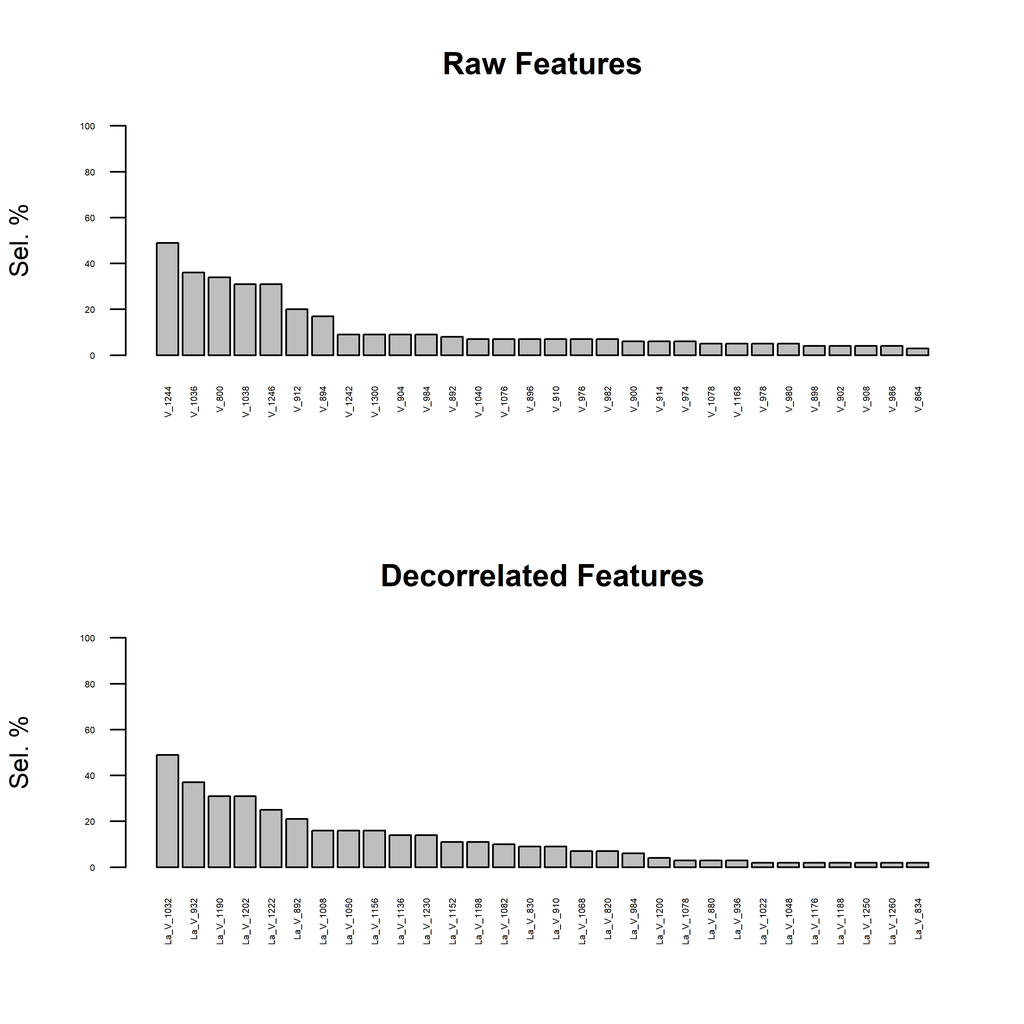

```r
par(mfrow=c(2,1),cex=0.9,cex.axis=0.8)

rawtopf <- cvRaw$featureFrequency/repetitions
crawtopf <- rawtopf

if (length(rawtopf) > 30)
{
  rawtopf <- rawtopf[1:30]
}
barplot(100*rawtopf,las=2,main="Raw Features",ylim=c(0,100.0),cex.names = 0.35,cex.axis = 0.35,ylab="Sel. %")

detopf <- cvDe$featureFrequency/repetitions
cdetopf <- detopf
names(cdetopf) <- str_remove_all(names(cdetopf),"Ba_")
names(cdetopf) <- str_remove_all(names(cdetopf),"La_")
if (length(detopf) > 30)
{
  detopf <- detopf[1:30]
}

barplot(100*detopf,las=2,main="Decorrelated Features",ylim=c(0,100.0),cex.names = 0.35,cex.axis = 0.35,ylab="Sel. %")
```

```r
par(op)
```

### 1.6.1 Final Table

```r
unlistdecorr <- selectedlist
names(unlistdecorr) <- NULL
unlistdecorr <- unique(names(unlist(unlistdecorr)))

finalTableDe <- univarDe$orderframe[deNames_in_dc,univariate_columns]

finalTableOr <- univar$orderframe[unique(c(topfiveOrg,unlistdecorr,names(crawtopf)[1:2],names(cdetopf)[1:2])),univariate_columns]

finalTable <- rbind(finalTableOr,finalTableDe)

deFromula <- character(length(theDeFormulas))
names(deFromula) <- names(theDeFormulas)

for (dx in names(deFromula))
{
  coef <- theDeFormulas[[dx]]
  cname <- names(theDeFormulas[[dx]])
  names(cname) <- cname
  for (cf in names(coef))
  {
    if (cf != dx)
    {
      if (coef[cf]>0)
      {
        deFromula[dx] <- paste(deFromula[dx],
                               sprintf("+ %5.3f*%s",coef[cf],cname[cf]))
      }
      else
      {
        deFromula[dx] <- paste(deFromula[dx],
                               sprintf("%5.3f*%s",coef[cf],cname[cf]))
      }
    }
  }
}

orgnamez <- rownames(finalTable)
orgnamez <- str_remove_all(orgnamez,"Ba_")
orgnamez <- str_remove_all(orgnamez,"La_")
finalTable$uAUC <- univar$orderframe[orgnamez,"ROCAUC"]
finalTable$raw_Freq <- crawtopf[orgnamez]
finalTable$La_Freq <- cdetopf[orgnamez]
finalTable$DecorFormula <- deFromula[rownames(finalTable)]
fscores <- attr(DEdataframe,"fscore")
finalTable$fscores <- fscores[rownames(finalTable)]

finalTable <- finalTable[order(-finalTable$ROCAUC),]

pander::pander(finalTable)
```

[output not shown]